# Introducing idealstan, a Package for Ideal-Point Modeling with Stan

Robert Kubinec

September 15, 2018

## Introduction

This notebook contains simulation and applications of a new R package for ideal point modeling using IRT known as [`idealstan`](https://github.com/saudiwin/idealstan). Ideal point modeling is commonly-used in the social sciences for estimating the latent positions of social actors within a common space, and is more broadly a form of dimension reduction. I created `idealstan` for two reasons:

1. Stan offers significant flexibility compared to existing approaches in using non-conjugate priors and a clearer programming interface. This flexibility allows for more options for end users in ideal point modeling that can be used to test new theories and hypotheses instead of being limited in the range and type of models available. In particular, Stan makes it easier to add hierarchical and time-series priors on to parameters, which opens the door to further analysis of dynamic and time-varying social phenomena.
2. Stan is relatively robust to large datasets, including the use of variational inference and soon parallel computing within chains, which makes dimension-reduction techniques more useful, especialy as interest increases in studying human interaction through social media and other online fora.

Existing packages for Bayesian ideal point modeling already exist, with [`pscl`](https://cran.r-project.org/web/packages/pscl/pscl.pdf) and [`MCMCpack`](https://cran.r-project.org/web/packages/MCMCpack/index.html) as the two most widely-used offerings based on Gibbs sampling. These packages are quite useful, but they are limited in the specific models that are hard-coded using different samplers. Furthermore, these packages can make it more difficult for applied users to quickly obtain important diagnostics of MCMC chains, such as split $\hat{R}$ values.

[`idealstan`](https://github.com/saudiwin/idealstan) is an effort to build on prior efforts but also to offer new models that satisfy the increasing variety of applications to which ideal point models are being put. Both `pscl` and `MCMCpack` were designed for ideal point modeling of legislatures in which yes and no votes are considered as a binary outcome (Clinton, Jackman, and Rivers, 2004; Martin and Quinn, 2002). However, legislators can also be absent at votes as well as abstain in parliamentary settings, which is also strategic behavior that should be modeled (Rosas, Shomer, and Haptonstahl, 2015). In addition, recently scholars have begun applying ideal point models to Twitter data (Barberá, 2015), massive campaign finance datasets (Bonica, 2014) and party campaign manifestos (Slapin and Proksch, 2008).

[`idealstan`](https://github.com/saudiwin/idealstan) is an attempt to provide an R-based framework for applied researchers to be able to use traditional ideal point models while taking advantage of Stan’s advances in MCMC estimation. In addition, [`idealstan`](https://github.com/saudiwin/idealstan) is aimed at expanding the available menu of models within a common interface so that applied researchers can quickly compare and examine different modeling choices on their outcomes. Finally, [`idealstan`](https://github.com/saudiwin/idealstan) is designed to be compatible with the growing array of `rstan`-based packages, including `bayesplot` and `shinystan` to leverage these packages’ considerable resources in terms of model evaluation.

In this notebook I first introduce ideal-point models and contrast them with “traditional” IRT, and then I demonstrate the `idealstan` package through simulations. I conclude with an analysis of the 114th Senate and show how `idealstan` enables new estimation of strategic legislature behavior during the previous Congress.

## Ideal Point Modeling and Traditional IRT

Ideal point modeling can be more broadly described as a situation in which different actors select from among competing policy alternatives based on the utility offered by each policy (Enelow and Hinich, 1984; [Poole, Lewis, Lo, et al., 2008](https://papers.ssrn.com/sol3/papers.cfm?abstract_id=1276082)). Supposing that the policies are evaluated on a uni-dimensional space, if the utility of the “Yes” position on the policy is greater than the utility of the “No” position to a particular actor, then that actor will choose that policy. While very simple, this model has a requirement that is different from much of traditional IRT estimation: the policy outcomes can have different meanings based on their position relative to the actor in the policy space.

For this reason, ideal-point modeling using IRT is built on the standard 2-PL model (Clinton, Jackman, and Rivers, 2004; Bafumi, Gelman, Park, et al., 2005), with one notable exception: the discrimination parameters must be un-constrained, while in traditional IRT the discrimination parameters are constrained to all be either positive or negative. This is the approach taken in the [`edstan`](https://cran.r-project.org/web/packages/edstan/vignettes/briefmanual.html) package, which already offers the full range IRT models using Stan.

A brief review of the mathematical notation will make the difference clear. The 2-PL IRT model takes the following form:

$$Y_{ij} = \alpha_j * x_i - \beta_j$$

where $Y_{ij}$ can be an outcome of any type (binary, ordinal, Poisson, etc.), $\alpha_j$ are the discrimination parameters that control the narrowness, hence discrimination, of each item $j$ in the latent space, $x_i$ are the person ability parameters that reflect the ability of a person to answer an item correctly, and $\beta_j$ is the difficulty or average probability/value of a correct response (i.e., the intercept). In the traditional IRT format, the $\alpha_j$ parameters are always positive because a higher value (i.e., a correct answer) is always associated with higher ability $x_i$, while a lower value (an incorrect answer) is associated with less ability.

By contrast, in an ideal point model a higher or lower value of $Y_{ij}$ could be associated with either a “correct” or “incorrect” answer. This happens because the latent space in an ideal point model is fundamentally a Euclidean distance that is rotation-invariant. The following figure makes this clear by showing a version of an ideal point model in which the ideal point (ability parameter) $x_i$ is represented by a Normal distribution while the Yes and No points of a proposed policy are vertical lines.

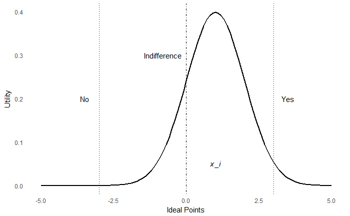

```r
data_frame(x=c(-5,5)) %>%
  ggplot(aes(x=x)) +
  theme_minimal() +
  theme(panel.grid=element_blank(),
        text=element_text(family='Times')) +
  ylab('Utility') +
  xlab('Ideal Points') +
  stat_function(fun=dnorm,args=list(mean=1),linetype=1,size=1) +
  geom_vline(xintercept = 3,linetype=3) +
    geom_vline(xintercept = -3,linetype=3) +
  geom_vline(xintercept=0,linetype=4) +
  annotate('text',x=c(-3.5,-.8,1,3.5),
           y=c(0.2,0.3,0.05,0.2),
           label=c('No',
                   'Indifference',
                   'italic(x_i)',
                   'Yes'),
           family='Times',
           parse=T)
```

If $x_i$ is to the right of the Indifference line, the person will vote Yes on the proposal, whereas if they are to the left, they will vote No. However, there is no reason that a different policy (item) couldn’t have the Yes and No positions switched such that a Yes vote would correspond to -2.5 and vice versa for the No vote. Thus the binary outcomes do not have the same interpretation as the standard IRT model because the relationship between the outcomes and the ability points is contingent.

If the discrimination parameters are unconstrained, Clinton, Jackman, and Rivers (2004) showed that the midpoint of the policy/item parameter, which is labeled on the plot as the indifference line, is identified as $-\frac{\delta_j}{\beta_j}$ in the original IRT model. Thus while the IRT ideal point model does not yield the individual Yes and No positions for each bill, it is sufficient to capture the calculus of the underlying utilities.

While this difference between ideal point models and standard IRT may seem trivial, it has serious consequences for modeling. The basic issue is the non-identifiability of the IRT model, which the switching polarity of the discrimination parameters only makes more difficult. Ultimately, it becomes necessary to constrain the polarity of some of the ability or discrimination parameters to identify the model. However, it is necessary to choose parameters which would avoid “splitting the likelihood”, such as constraining a legislator whose true ideal is near zero (Bafumi, Gelman, Park, et al., 2005).

`idealstan` exploits variational inference ([Kucukelbir, Ranganath, Gelman, et al., 2015](http://papers.nips.cc/paper/5758-automatic-variational-inference-in-stan.pdf)) to assist with finding parameters for identification. `idealstan` first estimates an IRT model with rotation-unidentified parameters, which is not a problem for a single VB run. Then `idealstan` can select those parameters which show the highest or lowest values, and these parameters are then constrained in terms of their polarity. This approach can quickly speed up the sometimes painful process of identifying a particular IRT ideal point model.

## Absence-inflated Ideal Point Model

In addition to the standard 2-PL model, `idealstan` implements a model that accounts for censoring in legislature data. While the standard models only account for yes and no votes, legislators can also be absent and in parliamentary systems as in Europe, abstentions are also common. However, if these two additional outcomes–absent and abstention–are treated as missing data, then the additional information about legislator behavior that could be in this data is lost. (Whether this loss of information means that the binary model is biased is a difficult question to answer as “bias” does not have a clear meaning with latent variables).

As a solution, I propose in Kubinec (2017a) to model abstentions as a middle category between yes and no votes by treating $Y_{ij}$ as an ordered logistic outcome $Y_{ijk}$ for $k$ in $\{1,2,3\}$ (no, abstain, yes), and to model absences via a hurdle model. While switching from a logit to an ordered logistic model is straightforward, modeling the censoring implied by legislator absences requires the estimation of additional parameters. Because in an ideal point model we only want to estimate a single set of person parameters (ideal points), I have to estimate additional item (bill) parameters. Supposing that $r=1$ if a legislator is absent and $r=0$ otherwise, the likelihood of the hurdle model takes the following form:

$$L(\beta,\alpha,X,Q,\gamma,\omega|Y_{k},Y_{r}) =
\prod_{I}^{i=1} \prod_{J}^{j=1}
\begin{cases}
\zeta(x_{i}'\gamma_j - \omega_j ) & \text{if } r=0, \text{ and} \\
(1-\zeta({x_{i}'\gamma_j - \omega_j}))L(\beta,\alpha,X|Y_{k1}) & \text{if } r=1
\end{cases}$$

The $\gamma_j$ discrimination and $\omega_j$ difficulty parameters represent the salience of a particular piece of legislation to an individual legislator $x_i$. Only if a bill clears the hurdle of salience will the legislator choose to vote on the legislation, i.e., reach the vote outcome model $L(\beta,\alpha,X)$. This device allows for the ideal points $x_i$ to adjust for the fact that the decision of a legislator to show up to vote on a particular bill may be strategic instead of random.

## Model Simulation

To identify the model, I also placed $N(0,1)$ parameters on the $x_i$ ideal points and additional polarity constraints on either the ideal points $x_i$ or the discrimination parameters $\gamma_j$ and $\alpha_j$. As a further restriction, I constrain one of the $\beta_j$ to equal zero. The full set of priors is as follows:

$$c_k - c_{k-1} \sim N(0,5)\\
\gamma_j \sim N(0,2)\\
\omega_j \sim N(0,5)\\
\beta_j \sim N(0,2)\\
\alpha_j \sim N(0,5)\\
x_i \sim N(0,1)$$

The $c_k$ parameters are the cutpoints for the $K-1$ ordinal outcomes. They are given a weakly informative prior on the differences between the cutpoints (see the prior help file in the Stan Development Github site). The rest of the priors are arbitrary as the scale of the latent variables is fixed only in the priors themselves.

To demonstrate the package, I first generate data from this data-generating process using a function `id_sim_gen()` built into `idealstan`:

```r
ord_ideal_sim <- id_sim_gen()
knitr::kable(as_data_frame(head(ord_ideal_sim@vote_matrix)))
```

| 1 | 2 | 3 | 4 | 5 | 6 | 7 | 8 | 9 | 10 | 11 | 12 | 13 | 14 | 15 | 16 | 17 | 18 | 19 | 20 | 21 | 22 | 23 | 24 | 25 | 26 | 27 | 28 | 29 | 30 | … |
| --- | --- | --- | --- | --- | --- | --- | --- | --- | --- | --- | --- | --- | --- | --- | --- | --- | --- | --- | --- | --- | --- | --- | --- | --- | --- | --- | --- | --- | --- | --- |
| 1 | 1 | 1 | 4 | 4 | 3 | 3 | 2 | 4 | 4 | 4 | 1 | 1 | 2 | 3 | 4 | 4 | 1 | 1 | 3 | 4 | 3 | 4 | 4 | 2 | 3 | 1 | 4 | 2 | 2 | … |
| 4 | 2 | 4 | 4 | 3 | 1 | 3 | 3 | 4 | 4 | 4 | 1 | 2 | 4 | 3 | 4 | 4 | 1 | 4 | 4 | 2 | 3 | 4 | 4 | 1 | 3 | 1 | 4 | 3 | 3 | … |
| 3 | 4 | 4 | 1 | 2 | 1 | 1 | 2 | 3 | 4 | 3 | 3 | 4 | 1 | 4 | 1 | 2 | 1 | 4 | 4 | 4 | 4 | 3 | 2 | 2 | 4 | 4 | 2 | 1 | 4 | … |
| 1 | 4 | 4 | 1 | 4 | 1 | 3 | 3 | 4 | 4 | 4 | 3 | 2 | 4 | 4 | 3 | 3 | 2 | 1 | 4 | 3 | 1 | 1 | 2 | 1 | 4 | 3 | 1 | 4 | 4 | … |
| 4 | 1 | 1 | 4 | 3 | 3 | 3 | 1 | 2 | 4 | 4 | 4 | 3 | 4 | 3 | 4 | 4 | 2 | 4 | 3 | 4 | 3 | 4 | 4 | 1 | 3 | 1 | 4 | 2 | 3 | … |
| 4 | 1 | 4 | 4 | 3 | 3 | 3 | 3 | 3 | 1 | 4 | 4 | 2 | 4 | 3 | 4 | 4 | 4 | 1 | 3 | 3 | 3 | 4 | 4 | 4 | 3 | 1 | 4 | 2 | 1 | … |

In this matrix, the legislators (persons) are represented by the rows and the bills (items) by the columns. The ordinal vote outcomes are numbered 1 to 3 (1=No,2=Abstain,3=Yes) and 4 represents absence.

I can then take this simulated data and put it into the `id_estimate` function. I also use the true values of the legislator ideal points $x_i$ for polarity constraints in order to be able to return the “true” latent variables. The `id_estimate` function loads pre-compiled stan code a la [`rstantools`](https://cran.r-project.org/web/packages/rstantools/index.html) and then returns an R object containing a compiled stan model.

```r
true_legis <- ord_ideal_sim@simul_data$true_legis
high_leg <- sort(true_legis,decreasing = T,index.return=T)
low_leg <- sort(true_legis,index.return=T)
ord_ideal_est <- id_estimate(idealdata=ord_ideal_sim,
                             model_type=4,
                             fixtype='constrained',
                             restrict_type='constrain_twoway',
                             restrict_ind_high = high_leg$ix[1:2],
                             restrict_ind_low=low_leg$ix[1:2],
                             refresh=500)
```

For testing simulation results, the package contains a residual plot for looking at differences between true and estimated values which are stored in the R object:

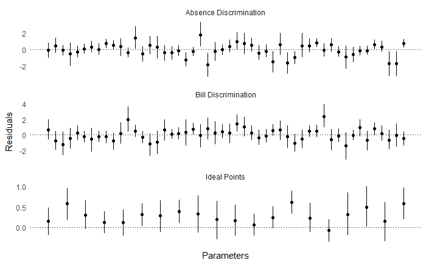

```r
id_plot_sims(ord_ideal_est,type='Residuals')
```

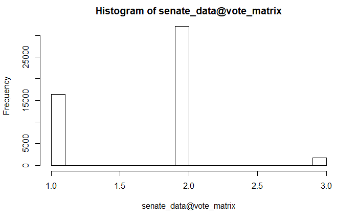

```r
data('senate114')
to_use <- senate114$votes
to_use <- apply(to_use, 2, function(x) {
  y <- recode(
    x,
    `1` = 2L,
    `6` = 1L,
    `9` = 3L
  )
  return(y)
})
rownames(to_use) <- rownames(senate114$legis.data)
# Need to drop Obama
senate_data <-
  id_make(
    vote_data = to_use[-1,],
    legis_data = slice(senate114$legis.data,-1),
    abs_vote = 3,
    yes_vote = 2,
    no_vote = 1,
    ordinal = F,
    exclude_level = c(3,7)
  )
hist(senate_data@vote_matrix)
```

Given a suitable object from `id_make`, the `id_estimate` function can estimate a variety of IRT ideal point models, including 2-PL, ordinal, hierarchical and dynamic IRT (using random-walk priors). For this run we set the `model_type` parameter to `2`, which represents a 2-PL model with absence inflation. Because this dataset is of a significant size, I use variational inference instead of the full sampler to demonstrate its use. I do not, however, use the automatic identification option `auto_id` because it is relatively easy to constrain particular legislator ideal points for the Senate. In this case, I constrain Ben Sasse, Marco Rubio, Berni Sanders, Ted Cruz, Harry Reid and Elizabeth Warren, all senators with pronounced ideological views.

After estimating the model, I can look at a graphical display of the ideal points with the `id_plot` function. The `id_plot` function produces a `ggplot2` object which can be further modified. The legislators are given colors based on their party affiliation. The general shape of the ideal point distribution reflects the nature of polarization in the US Congress, with relatively few moderates near the center of the distribution.

```r
sen_est <- id_estimate(senate_data,
                model_type = 2,
                 use_vb = T,
                 ncores=4,
                 nfix=2,
                 restrict_type='constrain_twoway',
                 restrict_params='legis',
                 restrict_ind_high = c(which(row.names(to_use)=='SASSE (R NE)'),
                                       which(row.names(to_use)=='CRUZ (R TX)'),
                                       which(row.names(to_use)=='RUBIO (R FL)')),
                 restrict_ind_low=c(which(row.names(to_use)=='SANDERS (Indep VT)'),
                                    which(row.names(to_use)=='REID (D NV)'),
                                    which(row.names(to_use)=='WARREN (D MA)')),
                 auto_id=F,
                 fixtype='constrained',
            seed=84520,
            refresh=500)
```

```
------------------------------------------------------------
EXPERIMENTAL ALGORITHM:
  This procedure has not been thoroughly tested and may be unstable
  or buggy. The interface is subject to change.
------------------------------------------------------------



Gradient evaluation took 0.042 seconds
1000 transitions using 10 leapfrog steps per transition would take 420 seconds.
Adjust your expectations accordingly!


Begin eta adaptation.
Iteration:   1 / 250 [  0%]  (Adaptation)
Iteration:  50 / 250 [ 20%]  (Adaptation)
Iteration: 100 / 250 [ 40%]  (Adaptation)
Iteration: 150 / 250 [ 60%]  (Adaptation)
Iteration: 200 / 250 [ 80%]  (Adaptation)
Success! Found best value [eta = 1] earlier than expected.

Begin stochastic gradient ascent.
  iter       ELBO   delta_ELBO_mean   delta_ELBO_med   notes
   100    -2e+004             1.000            1.000
   200    -2e+004             0.508            1.000
   300    -2e+004             0.339            0.015
   400    -2e+004             0.254            0.015
   500    -2e+004             0.204            0.002   MEDIAN ELBO CONVERGED

Drawing a sample of size 1000 from the approximate posterior...
COMPLETED.
```

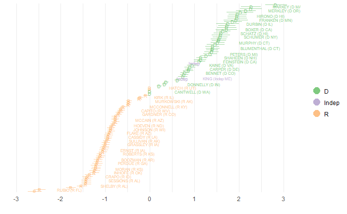

```r
id_plot(sen_est,legis_ci_alpha=0.7) + scale_colour_brewer(type='qual')
```

We can also plot the bill midpoints as a line of indifference that we overlay on top of the ideal points.

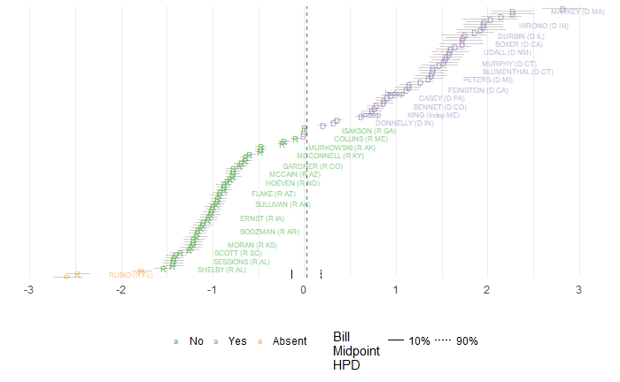

```r
id_plot(sen_est,legis_ci_alpha=0.1,bill_plot=205,
        abs_and_reg='Vote Points') + scale_colour_brewer(type='qual')
```

For this particular piece of legislation, the midpoint is right in the middle of the ideal point distribution, showing that the bill has very high discrimination. Also, the rug lines at the bottom of the plot, which show the HPD for the midpoint, indicate that the model is uncertain about the votes of only a handful of Senators on this bill.

We can similarly examine the absence midpoint for the same bill, which signifies the place on the ideal point spectrum at which a legislator is indifferent from showing up to vote. In this case, only very conservative Republicans chose not to show up to vote.

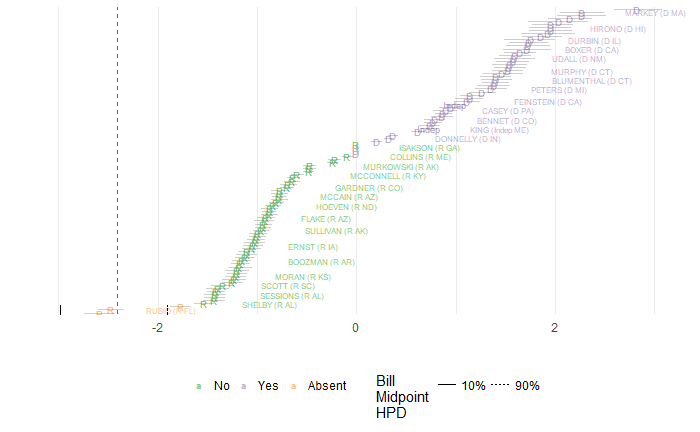

```r
id_plot(sen_est,legis_ci_alpha=0.1,bill_plot=205,
        abs_and_reg='Absence Points') + scale_colour_brewer(type='qual')
```

We can use the bill absence parameters to also see which bills showed the highest discrimination in terms of absences, or in other words, for which bills did the absence of legislators signify that they intentionally did not show up? To do this, I sort the discrimination parameters from the underlying Stan object and then merge them with the bill labels from voteview.org.

First we can look at the top 10 bills with liberal/Democrat discrimination:

| description |
| --- |
| To conform citizen suits under the Endangered Species Act of 1973. |
| To express the sense of the Senate that climate change is real and not a hoax. |
| To require the use of iron, steel, and manufactured goods produced in the United States in the construction of the Keystone XL Pipeline and facilities. |
| To promote energy efficiency. |
| To ensure that oil transported through the Keystone XL pipeline into the United States is used to reduce United States dependence on Middle Eastern oil. |
| To express the sense of Congress regarding federally protected land. |
| To express the sense of Congress regarding climate change. |
| To provide limits on the designation of new federally protected land. |
| To continue cleaning up fields and streams while protecting neighborhoods, generating affordable energy, and creating jobs. |
| To express the sense of Congress regarding climate change. |

Interestingly, Democrats appeared to be strategically absent most often on bills about climate change and the Keystone XL pipeline.

For conseratives the bills are as follows:

```r
bills %>%
  arrange(m_abs_ideal) %>%
  select(description) %>%
  slice(1:10)
```

| description |
| --- |
| To limit the availability of amounts authorized to be appropriated for overseas contingency operations pending relief from the spending limits under the Budget Control Act of 2011. |
| To improve the bill. |
| To strike the FOIA exemption. |
| To strengthen the Justice for Victims of Trafficking Act by incorporating additional bipartisan amendments. |
| To improve the requirements relating to removal of personal information from cyber threat indicators before sharing. |
| To protect information that is reasonably believed to be personal information or information that identifies a specific person. |
| To exempt from the capability and process within the Department of Homeland Security communication between a private entity and the Federal Bureau of Investigation or the United States Secret Service … |
| An original bill to improve cybersecurity in the United States through enhanced sharing of information about cybersecurity threats, and for other purposes. |
| An original concurrent resolution setting forth the congressional budget for the United States Government for fiscal year 2016 and setting forth the appropriate budgetary levels for fiscal years 2017 … |
| To improve the definitions of cybersecurity threat and cyber threat indicator. |

For Republicans, on the other hand, it appears that cybersecurity and inter-departmental information sharing were the laws in which they chose not to show up for ideological (or political) reasons. This could be due to concerns among the conservative base regarding government over-reach and collecting information.

## Conclusion

`idealstan` is an attempt to put state-of-the-art ideal point models along with the power of full Bayesian analysis in the hands of applied researchers in the social sciences. While the empirical examples presented were from the US Congress, the model can be used in any situation in which the assumptions of the ideal point model (i.e., unconstrained ideal point space) apply. While similar in function and form to the `edstan` package, the `idealstan` package has to use more complicated forms of identification because of the difficulty of leaving discrimination parameters unconstrained.

Moving forward, I intend to add in more functionality to smoothly operate with `shinystan` and `bayesplot`, as well as add further types of explanatory IRT models. The intention is to have a package on which applied researchers can run different ideal point models and then examine how different modeling choices affect the results. In addition, I will continue to build more visualization options so that the results are easily digestable and publishable.